# chapter3.Rmd

# ## Reading data

Let’s read the data

```r
library(dplyr)
alc<- read.table("http://s3.amazonaws.com/assets.datacamp.com/production/course_2218/datasets/alc.txt", sep=",", header=TRUE)
```

```r
print<-vars(alc)
```

```r
str(alc)
```

```
## 'data.frame':    382 obs. of  35 variables:
##  $ school    : Factor w/ 2 levels "GP","MS": 1 1 1 1 1 1 1 1 1 1 ...
##  $ sex       : Factor w/ 2 levels "F","M": 1 1 1 1 1 2 2 1 2 2 ...
##  $ age       : int  18 17 15 15 16 16 16 17 15 15 ...
##  $ address   : Factor w/ 2 levels "R","U": 2 2 2 2 2 2 2 2 2 2 ...
##  $ famsize   : Factor w/ 2 levels "GT3","LE3": 1 1 2 1 1 2 2 1 2 1 ...
##  $ Pstatus   : Factor w/ 2 levels "A","T": 1 2 2 2 2 2 2 1 1 2 ...
##  $ Medu      : int  4 1 1 4 3 4 2 4 3 3 ...
##  $ Fedu      : int  4 1 1 2 3 3 2 4 2 4 ...
##  $ Mjob      : Factor w/ 5 levels "at_home","health",..: 1 1 1 2 3 4 3 3 4 3 ...
##  $ Fjob      : Factor w/ 5 levels "at_home","health",..: 5 3 3 4 3 3 3 5 3 3 ...
##  $ reason    : Factor w/ 4 levels "course","home",..: 1 1 3 2 2 4 2 2 2 2 ...
##  $ nursery   : Factor w/ 2 levels "no","yes": 2 1 2 2 2 2 2 2 2 2 ...
##  $ internet  : Factor w/ 2 levels "no","yes": 1 2 2 2 1 2 2 1 2 2 ...
##  $ guardian  : Factor w/ 3 levels "father","mother",..: 2 1 2 2 1 2 2 2 2 2 ...
```

[output cut: 21 more lines]

# There were 382 observations and 35 variables. Two datasets are provided regarding the performance in two distinct subjects: Mathematics (mat) and Portuguese language (por) were joned using variables “school”, “sex”, “age”, “address”, “famsize”, “Pstatus”, “Medu”, “Fedu”, “Mjob”, “Fjob”, “reason”, “nursery”,“internet” as (student) identifiers. The relation between variables in joined data and its relation with aclohol consumption was evaluated

# # access the tidyverse libraries tidyr, dplyr, ggplot2

```r
alc <- mutate(alc, high_use = alc_use > 2)
```

```r
glimpse(alc)
```

```
## Observations: 382
## Variables: 35
## $ school     <fct> GP, GP, GP, GP, GP, GP, GP, GP, GP, GP, GP, GP, GP,...
## $ sex        <fct> F, F, F, F, F, M, M, F, M, M, F, F, M, M, M, F, F, ...
## $ age        <int> 18, 17, 15, 15, 16, 16, 16, 17, 15, 15, 15, 15, 15,...
## $ address    <fct> U, U, U, U, U, U, U, U, U, U, U, U, U, U, U, U, U, ...
## $ famsize    <fct> GT3, GT3, LE3, GT3, GT3, LE3, LE3, GT3, LE3, GT3, G...
## $ Pstatus    <fct> A, T, T, T, T, T, T, A, A, T, T, T, T, T, A, T, T, ...
## $ Medu       <int> 4, 1, 1, 4, 3, 4, 2, 4, 3, 3, 4, 2, 4, 4, 2, 4, 4, ...
## $ Fedu       <int> 4, 1, 1, 2, 3, 3, 2, 4, 2, 4, 4, 1, 4, 3, 2, 4, 4, ...
## $ Mjob       <fct> at_home, at_home, at_home, health, other, services,...
## $ Fjob       <fct> teacher, other, other, services, other, other, othe...
## $ reason     <fct> course, course, other, home, home, reputation, home...
## $ nursery    <fct> yes, no, yes, yes, yes, yes, yes, yes, yes, yes, ye...
## $ internet   <fct> no, yes, yes, yes, no, yes, yes, no, yes, yes, yes,...
```

[output cut: 22 more lines]

```r
alc %>% group_by(alc_use,age) %>% summarise(count = n())
```

```
## # A tibble: 41 x 3
## # Groups:   alc_use [9]
##    alc_use   age count
##      <dbl> <int> <int>
##  1     1      15    46
##  2     1      16    41
##  3     1      17    26
##  4     1      18    27
##  5     1      19     3
##  6     1      20     1
##  7     1.5    15     9
##  8     1.5    16    24
##  9     1.5    17    20
## 10     1.5    18    12
## # ... with 31 more rows
```

```r
alc %>% group_by(alc_use,sex) %>% summarise(count = n())
```

```
## # A tibble: 17 x 3
## # Groups:   alc_use [9]
##    alc_use sex   count
##      <dbl> <fct> <int>
##  1     1   F        89
##  2     1   M        55
##  3     1.5 F        41
##  4     1.5 M        27
##  5     2   F        27
##  6     2   M        31
##  7     2.5 F        25
##  8     2.5 M        17
##  9     3   F        11
## 10     3   M        21
## 11     3.5 F         3
## 12     3.5 M        14
## 13     4   F         1
## 14     4   M         8
## 15     4.5 M         3
## 16     5   F         1
## 17     5   M         8
```

```r
alc %>% group_by(alc_use,Medu) %>% summarise(count = n())
```

```
## # A tibble: 37 x 3
## # Groups:   alc_use [9]
##    alc_use  Medu count
##      <dbl> <int> <int>
##  1     1       0     1
##  2     1       1    18
##  3     1       2    41
##  4     1       3    33
##  5     1       4    51
##  6     1.5     1    10
##  7     1.5     2    22
##  8     1.5     3    12
##  9     1.5     4    24
## 10     2       1     5
## # ... with 27 more rows
```

```r
alc %>% group_by(alc_use,Fedu) %>% summarise(count = n())
```

```
## # A tibble: 35 x 3
## # Groups:   alc_use [9]
##    alc_use  Fedu count
##      <dbl> <int> <int>
##  1     1       0     2
##  2     1       1    28
##  3     1       2    42
##  4     1       3    38
##  5     1       4    34
##  6     1.5     1    16
##  7     1.5     2    15
##  8     1.5     3    19
##  9     1.5     4    18
## 10     2       1     9
## # ... with 25 more rows
```

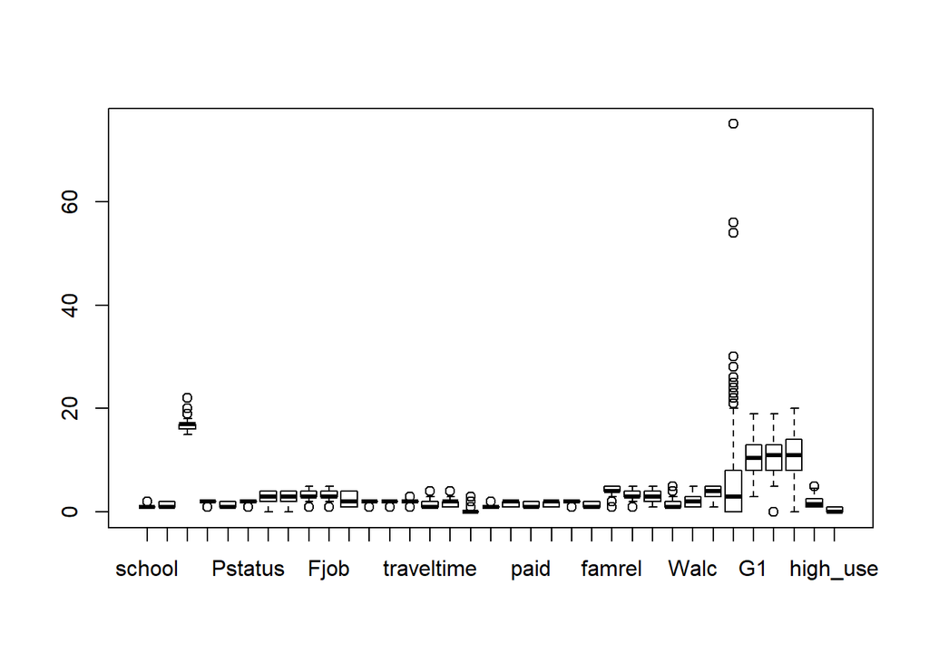

```r
alc %>% group_by(alc_use,age) %>% boxplot
```